# California Housing Price Analysis

Exploring what drives median house value across California using the classic California Housing dataset - income, location, and housing characteristics.

```python
import pandas as pd

df = pd.read_csv("housing.csv")
df.head()
```

|  | longitude | latitude | housing_median_age | total_rooms | total_bedrooms | population | households | median_income | median_house_value | ocean_proximity |
| --- | --- | --- | --- | --- | --- | --- | --- | --- | --- | --- |
| 0 | -122.23 | 37.88 | 41.0 | 880.0 | 129.0 | 322.0 | 126.0 | 8.3252 | 452600.0 | NEAR BAY |
| 1 | -122.22 | 37.86 | 21.0 | 7099.0 | 1106.0 | 2401.0 | 1138.0 | 8.3014 | 358500.0 | NEAR BAY |
| 2 | -122.24 | 37.85 | 52.0 | 1467.0 | 190.0 | 496.0 | 177.0 | 7.2574 | 352100.0 | NEAR BAY |
| 3 | -122.25 | 37.85 | 52.0 | 1274.0 | 235.0 | 558.0 | 219.0 | 5.6431 | 341300.0 | NEAR BAY |
| 4 | -122.25 | 37.85 | 52.0 | 1627.0 | 280.0 | 565.0 | 259.0 | 3.8462 | 342200.0 | NEAR BAY |

## Data Overview

```python
df.info()
print (df.describe())
print (df.shape)
```

```
<class 'pandas.core.frame.DataFrame'>
RangeIndex: 20640 entries, 0 to 20639
Data columns (total 10 columns):
 #   Column              Non-Null Count  Dtype
---  ------              --------------  -----
 0   longitude           20640 non-null  float64
 1   latitude            20640 non-null  float64
 2   housing_median_age  20640 non-null  float64
 3   total_rooms         20640 non-null  float64
 4   total_bedrooms      20433 non-null  float64
 5   population          20640 non-null  float64
 6   households          20640 non-null  float64
 7   median_income       20640 non-null  float64
 8   median_house_value  20640 non-null  float64
 9   ocean_proximity     20640 non-null  object
dtypes: float64(9), object(1)
memory usage: 1.6+ MB
          longitude      latitude  housing_median_age   total_rooms  \
count  20640.000000  20640.000000        20640.000000  20640.000000
mean    -119.569704     35.631861           28.639486   2635.763081
std        2.003532      2.135952           12.585558   2181.615252
min     -124.350000     32.540000            1.000000      2.000000
25%     -121.800000     33.930000           18.000000   1447.750000
50%     -118.490000     34.260000           29.000000   2127.000000
75%     -118.010000     37.710000           37.000000   3148.000000
max     -114.310000     41.950000           52.000000  39320.000000

       total_bedrooms    population    households  median_income  \
count    20433.000000  20640.000000  20640.000000   20640.000000
mean       537.870553   1425.476744    499.539680       3.870671
std        421.385070   1132.462122    382.329753       1.899822
min          1.000000      3.000000      1.000000       0.499900
25%        296.000000    787.000000    280.000000       2.563400
50%        435.000000   1166.000000    409.000000       3.534800
75%        647.000000   1725.000000    605.000000       4.743250
max       6445.000000  35682.000000   6082.000000      15.000100

       median_house_value
count        20640.000000
mean        206855.816909
std         115395.615874
min          14999.000000
25%         119600.000000
50%         179700.000000
75%         264725.000000
max         500001.000000
(20640, 10)
```

## Cleaning

```python
 df.isna().sum()
```

```
longitude               0
latitude                0
housing_median_age      0
total_rooms             0
total_bedrooms        207
population              0
households              0
median_income           0
median_house_value      0
ocean_proximity         0
dtype: int64
```

```python
df["total_bedrooms"]=df["total_bedrooms"].fillna(df["total_bedrooms"].median())
```

```python
df.isna().sum()
```

```
longitude             0
latitude              0
housing_median_age    0
total_rooms           0
total_bedrooms        0
population            0
households            0
median_income         0
median_house_value    0
ocean_proximity       0
dtype: int64
```

## Correlation Analysis

```python
df.corr(numeric_only=True)["median_house_value"].sort_values(ascending=False)
```

```
median_house_value    1.000000
median_income         0.688075
total_rooms           0.134153
housing_median_age    0.105623
households            0.065843
total_bedrooms        0.049457
population           -0.024650
longitude            -0.045967
latitude             -0.144160
Name: median_house_value, dtype: float64
```

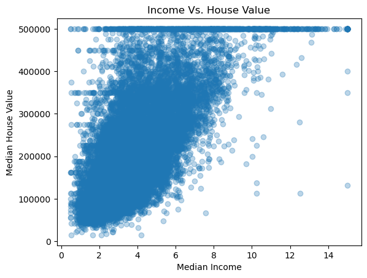

```python
import matplotlib.pyplot as plt

plt.scatter(df["median_income"], df["median_house_value"], alpha=0.3)
plt.xlabel("Median Income")
plt.ylabel("Median House Value")
plt.title("Income Vs. House Value")
plt.show()
```

```python
df.groupby("ocean_proximity")["median_house_value"].mean().sort_values(ascending=False)
```

```
ocean_proximity
ISLAND        380440.000000
NEAR BAY      259212.311790
NEAR OCEAN    249433.977427
<1H OCEAN     240084.285464
INLAND        124805.392001
Name: median_house_value, dtype: float64
```

## Location Analysis

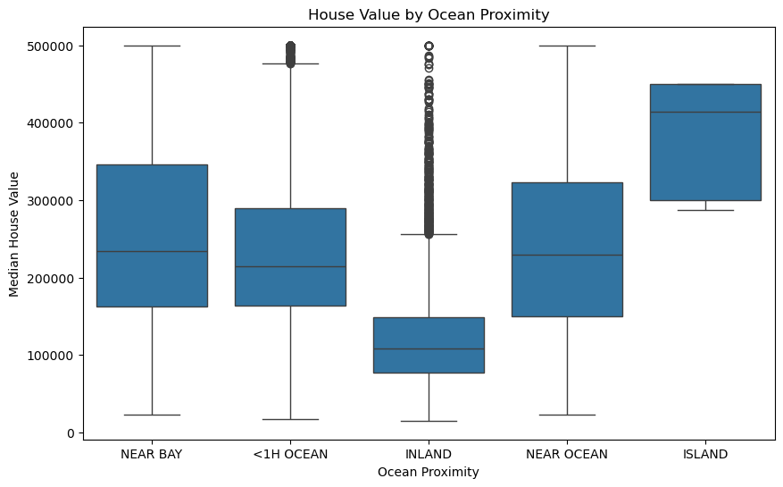

```python
import seaborn as sns

plt.figure(figsize=(10,6))
sns.boxplot(x="ocean_proximity", y="median_house_value", data=df)
plt.xlabel("Ocean Proximity")
plt.ylabel("Median House Value")
plt.title("House Value by Ocean Proximity")
plt.show()
```

## Findings

```python
df["ocean_proximity"].value_counts()
```

```
ocean_proximity
<1H OCEAN     9136
INLAND        6551
NEAR OCEAN    2658
NEAR BAY      2290
ISLAND           5
Name: count, dtype: int64
```

## Findings: What Drives House Value?

**1. Income is the strongest numeric predictor.** Median income correlates with the house value at 0.69 - far stronger than any other numeric feature (room count, house age, population, etc.). Higher income areas reliably have higher homw values, though the relationship isn't perfectly linear - at higher incomes, prices vary more widely, suggesting other factors (location, house age) matter more once a baseline income levele is met.

**2. Location matters - but "ISLAND" is a statistical trap.** Grouping by ocean proximity shows INLAND homes are consistently the cheapest category, averaging ~$124,000 - roughly half the price of any coastal category. NEAR BAY, NEAR OCEAN, and <1H OCEAN cluster closely together in the $240,000-$260,000 range.

ISLAND shows the highest average ($380,440), but this is based on only 5 properties out of 20, 640 - too small a sample to draw a reliable conclusion. This is flaggged rather than treated as a genuine finding.

**3. Data Caveat.** House value in this dataset are capped at $500,01 - visible as a flat line of repeated maximum value in both the scatter plot and boxplot outliers. This slightly understates the true spread of high-end home prices and should be noted for anyone using this dataset for further modeling.